# HaydenFeedback_r4ds_27&28

Jared Stier

November 13, 2017

# General comments

- Your file isn’t rmarkdown, so I can’t just knit it and run everything
- You have two blocks of code named `setup`. Knitting will fail if you have more than one chunk of code named the same thing. If the code you want in a second setup doesn’t produce any results, you could always set `echo=FALSE` or `include=FALSE` so the code doesn’t show up in the output.
- I removed the word `setup` from line 61
- You also have a third `setup` within a larger code chunk at line 94. Try to load all libraries you need in the initial set up at the top, even if you don’t need them until later.
  - I commented out line 94. Now everything fully ran.
- Since you didn’t have this as a rmd file, this is probably just accidental. But the number of `#`’s in your headers seem to be reversed. Just one `#` is the largest header.

# 27.3.1

## Question 1

I’d be curious to see your resume. I didn’t see it in the repo

## Question 2

Try actually creating the footnote in an rmd file when you get a chance. I needed a couple tries to set it up successfully, it’s a little weird

# 27.4.7

## Question 1

You could have added a couple graphs here. I believe their intent was to write code without the echo parameter so you can show someone the results, but also how you got to it. I did that with a few charts below.

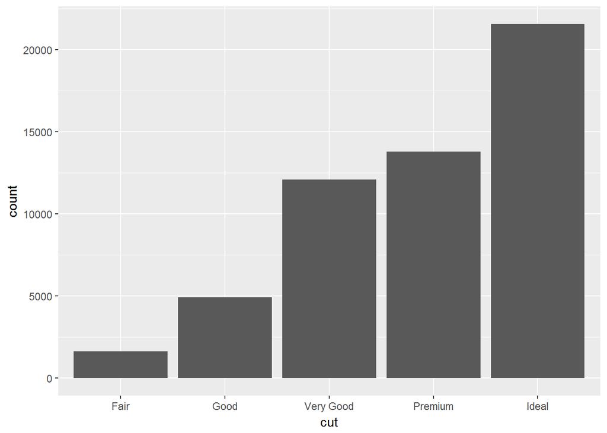

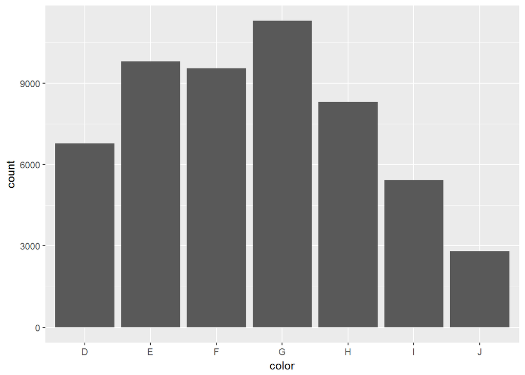

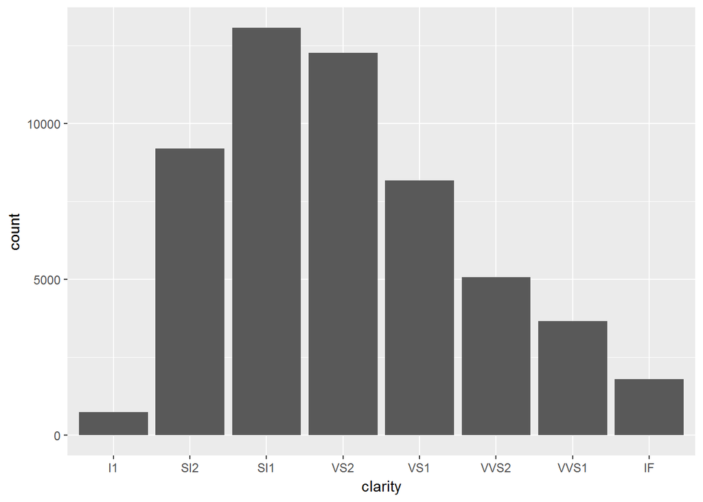

## Question 3

You never closed off the code chunk that starts at line 102 before trying to start question 4.

Unless I’m reading this wrong, I don’t see where you used `comma()` to change the output.

## Question 4

The point of this question is to work on dependencies. Calling `lubridate::now()` in each code chunk defeats the purpose. Assign `lubridate::now()` to a variable in the first code chunk, then try calling that variable in a later chunk. Then try messing with the caching to get an output different than what it would be if you ran each code chunk in succession.

# 28.2.1

## Question 2

What you did helps, but I think you could have gone step further by supplying a linear model for each of the car classes. Try moving the aesthetic `color = class` from the `geom_point()` to the initialization of the plot in `ggplot()`. You could also leave it in `geom_point()`, but also add it to `geom_smooth()`. Both options will have it applied everywhere. See example below:

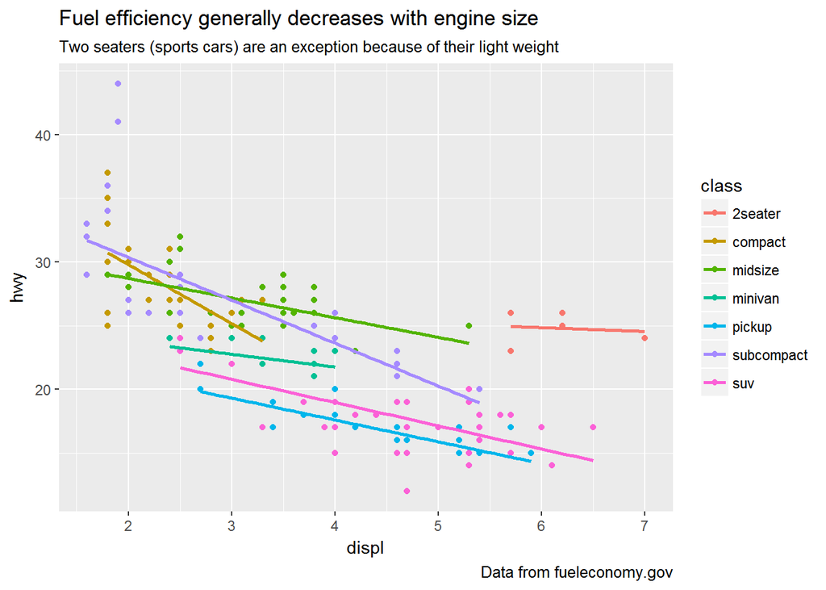

# 28.3.1

## Question 3

I’m not sure I know what you were doing here. I think the important message they wanted to get across is that if you add a label, it gets applied to all facets by default. To add the label to just one facet, include it as part of your label tibble. Ex below, this label should only show up in the 2seater facet.

```
label <- tibble(
  displ = Inf,
  hwy = Inf,
  class = "2seater",
  label = "Something about 2 seaters"
)
```

# 28.4.4

## Question 3

You missed out on one aspect they were looking for, changing the scale of the x-axis to break every 4 years.

I approached this by making a vector with all of the relevent years, then put it as part of the x_scale within the chart.

```
years <- lubridate::make_date(seq(year(min(presidential$start)),
             year(max(presidential$end)),
             by = 4), 1, 1)

ggplot() + ......+
  scale_x_date(NULL, breaks = years, date_labels = "'%y")
```